# Master’s thesis: “Model-based Adjustments for Non-concurrent Comparisons in Platform Trials”

Pavla Krotka

2023

```r
# Load results

results_setting_1_alpha <- read_csv("results/results_setting_1_alpha.csv")
results_setting_1_pow <- read_csv("results/results_setting_1_pow.csv")

results_setting_2_alpha <- read_csv("results/results_setting_2_alpha.csv") %>%
  mutate(trend = case_when(trend=="seasonal" & n_wave==1 ~ "seasonal_1",
                           trend=="seasonal" & n_wave==2 ~ "seasonal_2",
                           TRUE ~ trend))
results_setting_2_pow <- read_csv("results/results_setting_2_pow.csv") %>%
  mutate(trend = case_when(trend=="seasonal" & n_wave==1 ~ "seasonal_1",
                           trend=="seasonal" & n_wave==2 ~ "seasonal_2",
                           TRUE ~ trend))

results_setting_3_alpha <- read_csv("results/results_setting_3_alpha.csv") %>%
  mutate(trend = case_when(trend=="seasonal" & n_wave==1 ~ "seasonal_1",
                           trend=="seasonal" & n_wave==2 ~ "seasonal_2",
                           TRUE ~ trend))
results_setting_3_pow <- read_csv("results/results_setting_3_pow.csv") %>%
  mutate(trend = case_when(trend=="seasonal" & n_wave==1 ~ "seasonal_1",
                           trend=="seasonal" & n_wave==2 ~ "seasonal_2",
                           TRUE ~ trend))

results_setting_4_alpha <- read_csv("results/results_setting_4_alpha.csv") %>%
  mutate(trend = case_when(trend=="seasonal" & n_wave==1 ~ "seasonal_1",
                           trend=="seasonal" & n_wave==2 ~ "seasonal_2",
                           TRUE ~ trend))
results_setting_4_pow <- read_csv("results/results_setting_4_pow.csv") %>%
  mutate(trend = case_when(trend=="seasonal" & n_wave==1 ~ "seasonal_1",
                           trend=="seasonal" & n_wave==2 ~ "seasonal_2",
                           TRUE ~ trend))
```

```r
# Names for trend patterns
trend_names <- c(linear = "Linear trend", stepwise_2 = "Stepwise trend", inv_u = "Inverted-U trend", seasonal_1 = "Seasonal trend; 1 cycle", seasonal_2 = "Seasonal trend; 2 cycles")

# Names for splines degrees
degree_names <- c(`1` = "Linear splines", `2` = "Quadratic splines", `3` = "Cubic splines")

# Color palette
my_palette = c("fixmodel" = "brown3",
               "fixmodel_cal" = "dodgerblue3",
               "poolmodel" = "mediumseagreen",
               "sepmodel" = "gray25",
               "mixmodel" = "deepskyblue2",
               "mixmodel_cal" = "goldenrod2",
               "mixmodel_AR1" = "lightsalmon4",
               "mixmodel_AR1_cal" = "mediumorchid3",
               "splines" = "lightpink3",
               "splines_cal" = "skyblue4")

#show_col(my_palette)

# Prediction interval for T1E
p <- 0.025
alpha <- 0.05
nsim <- 10000
sd <- sqrt(p*(1-p)/nsim)
z.alpha <- qnorm(1-alpha/2,0,1)
pred_int <- c(p-z.alpha*sd,p+z.alpha*sd)
#pred_int
```

# Introduction

This file contains all code to reproduce the figures presented in Chapter 3, as well as plots from Appendix A.1 in the master’s thesis *“Model-based Adjustments for Non-concurrent Comparisons in Platform Trials”*.

# Investigated models

**Fixed effect models:**

- with period adjustment
- with calendar time adjustment

**Mixed effect models:**

- with period adjustment
- with calendar time adjustment
- with period adjustment and AR1 covariance structure
- with calendar time adjustment and AR1 covariance structure

**Spline regression:**

- B-splines with knots placed according to periods
- B-splines with knots placed according to calendar time intervals

# Considered designs

- **Setting 1:** Trial with $K=10$ experimental arms and linear time trend pattern, where we vary the strength of the time trend, as well as the timings of adding new treatment arms. We focus on comparing the efficacy of arm $M=5$ to the shared control group, but also discuss how the power of individual treatment-control comparisons depends on the entry order of the treatment arms. In this setting, we aim at evaluating the generalization of the model-based approach with period adjustment to trials with more than two experimental arms.
- **Setting 2:** Trial with $K=4$ experimental arms, where we evaluate arm $M=3$, while varying the pattern and strength of the time trend, as well as the size of the calendar time unit. Here, we aim at comparing the definition of time as calendar time intervals to the period definition in fixed effect models.
- **Setting 3:** Trial with $K=4$ experimental arms, where we evaluate arm $M=3$, while varying the pattern and strength of the time trend. In this setting, we evaluate the performance of the mixed models
- **Setting 4:** Trial with $K=7$ experimental arms, where we evaluate arm $M=3$, while varying the pattern and strength of the time trend. In this setting, we assess the properties of the spline regression.

Table below summarizes the considered simulation settings and parameters. We simulated 10,000 replicates of each scenario to estimate the type I error rate and statistical power.

Simulation settings and parameters considered in the simulation study.

| Setting | $K$ | $d$ | $\lambda$ | Trend pattern | Calendar time unit size | Objective |
| --- | --- | --- | --- | --- | --- | --- |
| 1 | 10 | $d_i = d \cdot (i-1)$ with $d \in [0, 500]$ with increments of 25; for $i \in \{1,\ldots,10\}$ | [-0.5, 0.5] with increments of 0.125 | Linear | _ | Evaluate the generalization of the model-based approach with period adjustment |
| 2 | 4 | $d_i = 250 \cdot (i-1)$ for $i \in \{1,\ldots4\}$ | [-0.5, 0.5] with increments of 0.125 | Linear, stepwise, inverted-U, seasonal | [25, 750] with increments of 25 | Evaluate the definition of time as calendar time intervals |
| 3 | 4 | $d_i = 250 \cdot (i-1)$ for $i \in \{1,\ldots,4\}$ | [-0.5, 0.5] with increments of 0.125 | Linear, stepwise, inverted-U, seasonal | 100 | Evaluate the mixed models |
| 4 | 7 | $\mathbf{d}$ = (0, 250, 250, 500, 500, 750, 750) | [-0.5, 0.5] with increments of 0.125 | Linear, stepwise, inverted-U, seasonal | 100 | Evaluate the spline regression |

## Time trend patterns

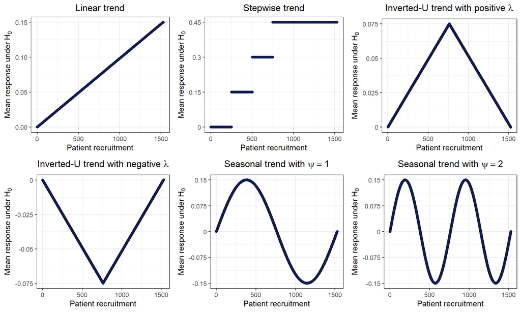

```r
# Time trend patterns

data_lin <- datasim_cont(num_arms = 4, n_arm = 250, d = 250*c(0:3), theta=rep(0, 4), lambda = rep(0.15, 5), sigma = 1, trend = "linear", full = T)$Data

data_step <- datasim_cont(num_arms = 4, n_arm = 250, d = 250*c(0:3), theta=rep(0, 4), lambda = rep(0.15, 5), sigma = 1, trend = "stepwise_2", full = T)$Data

data_inv_u_pos <- datasim_cont(num_arms = 4, n_arm = 250, d = 250*c(0:3), theta=rep(0, 4), lambda = rep(0.15, 5), sigma = 1, trend = "inv_u", N_peak = 764, full = T)$Data

data_inv_u_neg <- datasim_cont(num_arms = 4, n_arm = 250, d = 250*c(0:3), theta=rep(0, 4), lambda = rep(-0.15, 5), sigma = 1, trend = "inv_u", N_peak = 764, full = T)$Data

data_seasonal_1 <- datasim_cont(num_arms = 4, n_arm = 250, d = 250*c(0:3), theta=rep(0, 4), lambda = rep(0.15, 5), sigma = 1, trend = "seasonal", n_wave = 1, full = T)$Data

data_seasonal_2 <- datasim_cont(num_arms = 4, n_arm = 250, d = 250*c(0:3), theta=rep(0, 4), lambda = rep(0.15, 5), sigma = 1, trend = "seasonal", n_wave = 2, full = T)$Data

ggarrange(ggplot(data_lin) +
            geom_point(aes(x=j, y=means), color="#111d4f") +
            theme_bw() +
            theme(plot.title = element_text(hjust = 0.5)) +
            labs(x="Patient recruitment", y=TeX("Mean response under $H_0$"), title = "Linear trend"),

          ggplot(data_step) +
            geom_point(aes(x=j, y=means), color="#111d4f") +
            theme_bw() +
            theme(plot.title = element_text(hjust = 0.5)) +
            labs(x="Patient recruitment", y=TeX("Mean response under $H_0$"), title = "Stepwise trend") +
            scale_y_continuous(breaks = seq(0, 0.45, by=0.15), labels = seq(0, 0.45, by=0.15)),

          ggplot(data_inv_u_pos) +
            geom_point(aes(x=j, y=means), color="#111d4f") +
            theme_bw() +
            theme(plot.title = element_text(hjust = 0.5)) +
            labs(x="Patient recruitment", y=TeX("Mean response under $H_0$"), title = TeX("Inverted-U trend with positive $\\lambda$")) +
            scale_y_continuous(breaks = seq(0, 0.075, length.out=4), labels = seq(0, 0.075, length.out=4)),

          ggplot(data_inv_u_neg) +
            geom_point(aes(x=j, y=means), color="#111d4f") +
            theme_bw() +
            theme(plot.title = element_text(hjust = 0.5)) +
            labs(x="Patient recruitment", y=TeX("Mean response under $H_0$"), title = TeX("Inverted-U trend with negative $\\lambda$")) +
            scale_y_continuous(breaks = seq(-0.075, 0, length.out=4), labels = seq(-0.075, 0, length.out=4)),

          ggplot(data_seasonal_1) +
            geom_point(aes(x=j, y=means), color="#111d4f") +
            theme_bw() +
            theme(plot.title = element_text(hjust = 0.5)) +
            labs(x="Patient recruitment", y=TeX("Mean response under $H_0$"), title = TeX("Seasonal trend with $\\psi=1$")) +
            scale_y_continuous(breaks = seq(-0.15, 0.15, length.out=5), labels = seq(-0.15, 0.15, length.out=5)),

          ggplot(data_seasonal_2) +
            geom_point(aes(x=j, y=means), color="#111d4f") +
            theme_bw() +
            theme(plot.title = element_text(hjust = 0.5)) +
            labs(x="Patient recruitment", y=TeX("Mean response under $H_0$"), title = TeX("Seasonal trend with $\\psi=2$")) +
            scale_y_continuous(breaks = seq(-0.15, 0.15, length.out=5), labels = seq(-0.15, 0.15, length.out=5)),
          ncol = 3, nrow = 2)
```

```r
ggsave("figures/trend_patterns.png", width = 10, height = 6)
```

# SETTING 1 - 10 treatment arms

## Plots from Chapter 3

### Scenario illustration

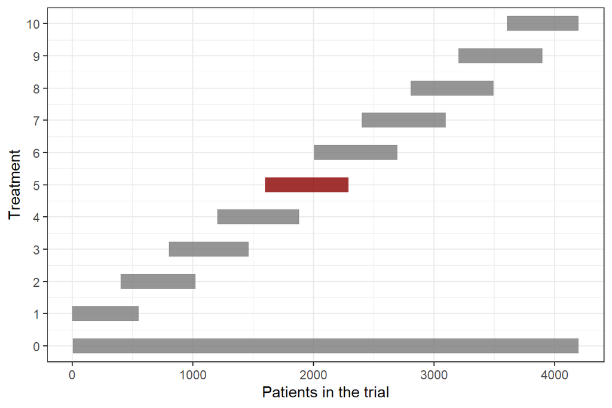

```r
d <- 400

trial_data <- datasim_cont(num_arms = 10, n_arm = 250, d = d*c(0:9), theta = rep(0, 10), lambda = rep(0.5, 11), sigma = 1, trend = "stepwise_2", full = T)$Data


plot_trial(trial_data$treatment) +
  scale_color_manual(values = c(rep("gray48", 5), "darkred", rep("gray48", 5)))
```

```r
ggsave("figures/trial_10arms.png", width = 6, height = 4)
```

### Results

- Evaluated arm: 5
- $d=400$
- $n=250$ per experimental treatment arm
- T1E and power with respect to the strength of the time trend $\lambda$

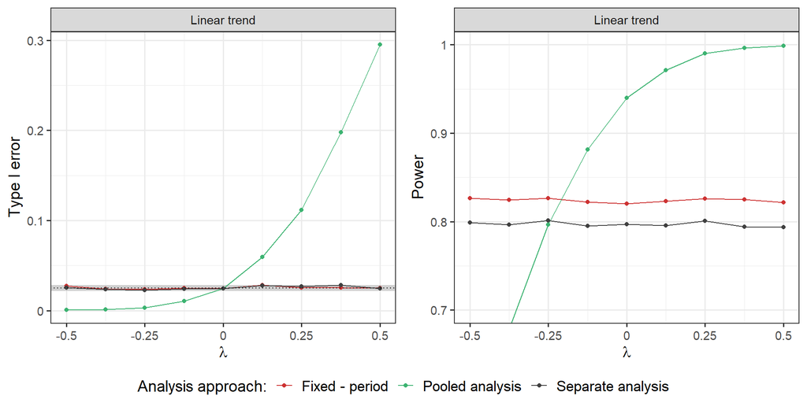

```r
ggarrange(ggplot(results_setting_1_alpha %>% filter(study_arm==5 & d2==400)) +
            annotate("rect", xmin = -Inf, xmax = Inf, ymin = pred_int[1], ymax = pred_int[2], fill = "gray54", alpha = 0.4) +
            geom_line(aes(lambda0, reject_h0, color=model)) +
            geom_point(aes(lambda0, reject_h0, color=model)) +
            labs(x=TeX("$\\lambda$"), y="Type I error", color="Analysis approach:") +
            geom_hline(aes(yintercept = 0.025), linetype = "dotted") +
            facet_grid(~ trend,
                       labeller = labeller(trend  = as_labeller(trend_names))) +
            scale_x_continuous(labels = function(x) sub(".0+$", "", x)) +
            scale_y_continuous(labels = function(x) sub(".0+$", "", x)) +
            #coord_cartesian(ylim = c(0, 0.3)) +
            scale_color_manual(labels = c("Fixed - period", "Pooled analysis", "Separate analysis"), values = my_palette, limits = force) +
            theme_bw(base_size = 13.8) +
            theme(legend.text=element_text(size = 13)),

          ggplot(results_setting_1_pow %>% filter(study_arm==5 & d2==400)) +
            geom_line(aes(lambda0, reject_h0, color=model)) +
            geom_point(aes(lambda0, reject_h0, color=model)) +
            labs(x=TeX("$\\lambda$"), y="Power", color="Analysis approach:") +
            facet_grid(~ trend,
                       labeller = labeller(trend  = as_labeller(trend_names))) +
            scale_x_continuous(labels = function(x) sub(".0+$", "", x)) +
            scale_y_continuous(labels = function(x) sub(".0+$", "", x)) +
            coord_cartesian(ylim = c(0.70, 1)) +
            scale_color_manual(labels = c("Fixed - period", "Pooled analysis", "Separate analysis"), values = my_palette, limits = force) +
            theme_bw(base_size = 13.8) +
            theme(legend.text=element_text(size = 13)),

          common.legend = T, legend = "bottom") +
  bgcolor("white") +
  border("white")
```

```r
ggsave("figures/fixmodel_alpha_pow_lambda.png", width = 10, height = 5)
```

- Evaluated arm: 5
- $\lambda=0.5$
- $n=250$ per experimental treatment arm
- T1E and power with respect to the timing of adding the treatment arms

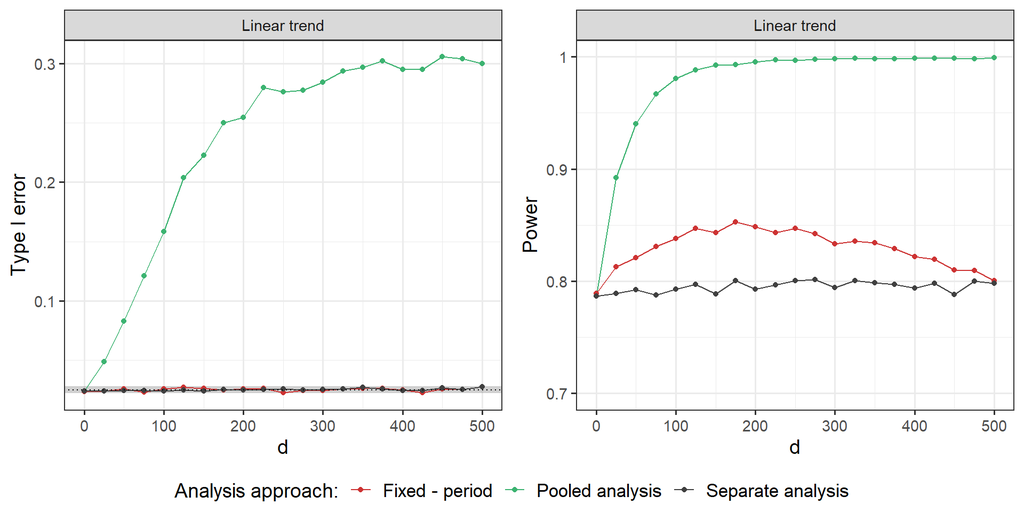

```r
ggarrange(ggplot(results_setting_1_alpha %>% filter(study_arm==5 & lambda0==0.5)) +
            annotate("rect", xmin = -Inf, xmax = Inf, ymin = pred_int[1], ymax = pred_int[2], fill = "gray54", alpha = 0.4) +
            geom_line(aes(d2, reject_h0, color=model)) +
            geom_point(aes(d2, reject_h0, color=model)) +
            labs(x=TeX("$d$"), y="Type I error", color="Analysis approach:") +
            geom_hline(aes(yintercept = 0.025), linetype = "dotted") +
            facet_grid(~ trend,
                       labeller = labeller(trend  = as_labeller(trend_names))) +
            scale_y_continuous(labels = function(x) sub(".0+$", "", x)) +
            #coord_cartesian(ylim = c(0, 0.3)) +
            scale_color_manual(labels = c("Fixed - period", "Pooled analysis", "Separate analysis"), values = my_palette, limits = force) +
            theme_bw(base_size = 13.8) +
            theme(legend.text=element_text(size = 13)),

          ggplot(results_setting_1_pow %>% filter(study_arm==5 & lambda0==0.5)) +
            geom_line(aes(d2, reject_h0, color=model)) +
            geom_point(aes(d2, reject_h0, color=model)) +
            labs(x=TeX("$d$"), y="Power", color="Analysis approach:") +
            facet_grid(~ trend,
                       labeller = labeller(trend  = as_labeller(trend_names))) +
            scale_y_continuous(labels = function(x) sub(".0+$", "", x)) +
            coord_cartesian(ylim = c(0.70, 1)) +
            scale_color_manual(labels = c("Fixed - period", "Pooled analysis", "Separate analysis"), values = my_palette, limits = force) +
            theme_bw(base_size = 13.8) +
            theme(legend.text=element_text(size = 13)),

          common.legend = T, legend = "bottom") +
  bgcolor("white") +
  border("white")
```

```r
ggsave("figures/fixmodel_alpha_pow_d.png", width = 10, height = 5)
```

- $\lambda=0.5$
- $d=200$
- $n=250$ per experimental treatment arm
- T1E and power with respect to the index of the evaluated arm

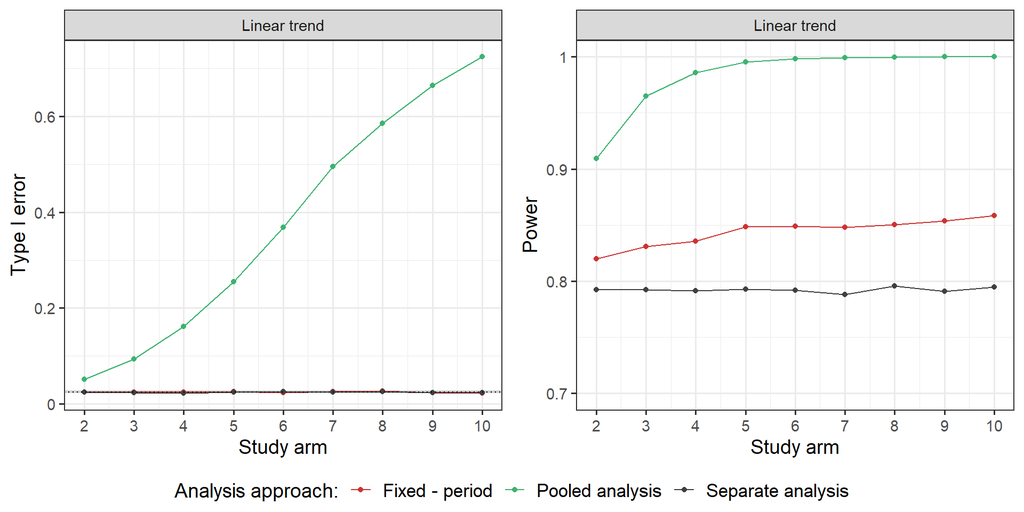

```r
ggarrange(ggplot(results_setting_1_alpha %>% filter(d2==200 & lambda0==0.5)) +
            annotate("rect", xmin = -Inf, xmax = Inf, ymin = pred_int[1], ymax = pred_int[2], fill = "gray54", alpha = 0.4) +
            geom_line(aes(study_arm, reject_h0, color=model)) +
            geom_point(aes(study_arm, reject_h0, color=model)) +
            labs(x="Study arm", y="Type I error", color="Analysis approach:") +
            geom_hline(aes(yintercept = 0.025), linetype = "dotted") +
            facet_grid(~ trend,
                       labeller = labeller(trend  = as_labeller(trend_names))) +
            #coord_cartesian(ylim = c(0, 0.3)) +
            scale_color_manual(labels = c("Fixed - period", "Pooled analysis", "Separate analysis"), values = my_palette, limits = force) +
            scale_x_continuous(breaks = c(1:10), labels = c(1:10)) +
            scale_y_continuous(labels = function(x) sub(".0+$", "", x)) +
            theme_bw(base_size = 13.8) +
            theme(legend.text=element_text(size = 13)),

          ggplot(results_setting_1_pow %>% filter(d2==200 & lambda0==0.5)) +
            geom_line(aes(study_arm, reject_h0, color=model)) +
            geom_point(aes(study_arm, reject_h0, color=model)) +
            labs(x="Study arm", y="Power", color="Analysis approach:") +
            facet_grid(~ trend,
                       labeller = labeller(trend  = as_labeller(trend_names))) +
            coord_cartesian(ylim = c(0.70, 1)) +
            scale_color_manual(labels = c("Fixed - period", "Pooled analysis", "Separate analysis"), values = my_palette, limits = force) +
            scale_x_continuous(breaks = c(1:10), labels = c(1:10)) +
            scale_y_continuous(labels = function(x) sub(".0+$", "", x)) +
            theme_bw(base_size = 13.8) +
            theme(legend.text=element_text(size = 13)),

          common.legend = T, legend = "bottom") +
  bgcolor("white") +
  border("white")
```

```r
ggsave("figures/fixmodel_alpha_pow_study_arm.png", width = 10, height = 5)
```

## Plots from Appendix

- $d=400$
- $n=250$ per experimental treatment arm
- Rows - Evaluated arm
- T1E and power with respect to the strength of the time trend $\lambda$

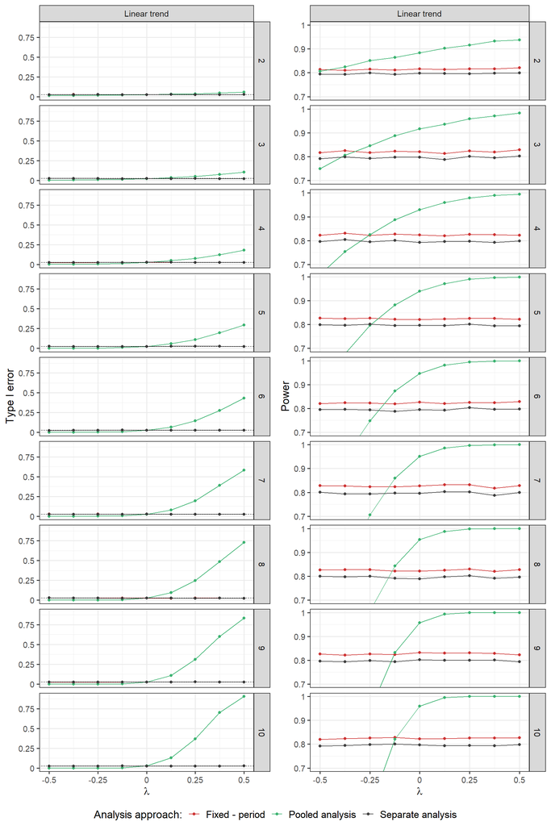

```r
ggarrange(ggplot(results_setting_1_alpha %>% filter(d2==400)) +
            annotate("rect", xmin = -Inf, xmax = Inf, ymin = pred_int[1], ymax = pred_int[2], fill = "gray54", alpha = 0.4) +
            geom_line(aes(lambda0, reject_h0, color=model)) +
            geom_point(aes(lambda0, reject_h0, color=model)) +
            labs(x=TeX("$\\lambda$"), y="Type I error", color="Analysis approach:") +
            geom_hline(aes(yintercept = 0.025), linetype = "dotted") +
            facet_grid(study_arm ~ trend,
                       labeller = labeller(trend  = as_labeller(trend_names))) +
            scale_x_continuous(labels = function(x) sub(".0+$", "", x)) +
            scale_y_continuous(labels = function(x) sub(".0+$", "", x)) +
            #coord_cartesian(ylim = c(0, 0.3)) +
            scale_color_manual(labels = c("Fixed - period", "Pooled analysis", "Separate analysis"), values = my_palette, limits = force) +
            theme_bw(base_size = 13.8) +
            theme(legend.text=element_text(size = 13)),

          ggplot(results_setting_1_pow %>% filter(d2==400)) +
            geom_line(aes(lambda0, reject_h0, color=model)) +
            geom_point(aes(lambda0, reject_h0, color=model)) +
            labs(x=TeX("$\\lambda$"), y="Power", color="Analysis approach:") +
            facet_grid(study_arm ~ trend,
                       labeller = labeller(trend  = as_labeller(trend_names))) +
            scale_x_continuous(labels = function(x) sub(".0+$", "", x)) +
            scale_y_continuous(labels = function(x) sub(".0+$", "", x)) +
            coord_cartesian(ylim = c(0.70, 1)) +
            scale_color_manual(labels = c("Fixed - period", "Pooled analysis", "Separate analysis"), values = my_palette, limits = force) +
            theme_bw(base_size = 13.8) +
            theme(legend.text=element_text(size = 13)),

          common.legend = T, legend = "bottom") +
  bgcolor("white") +
  border("white")
```

```r
ggsave("figures/fixmodel_alpha_pow_lambda_all_arms.png", width = 10, height = 15)
```

- $\lambda=0.5$
- $n=250$ per experimental treatment arm
- Rows - Evaluated arm
- T1E and power with respect to the timing of adding the treatment arms

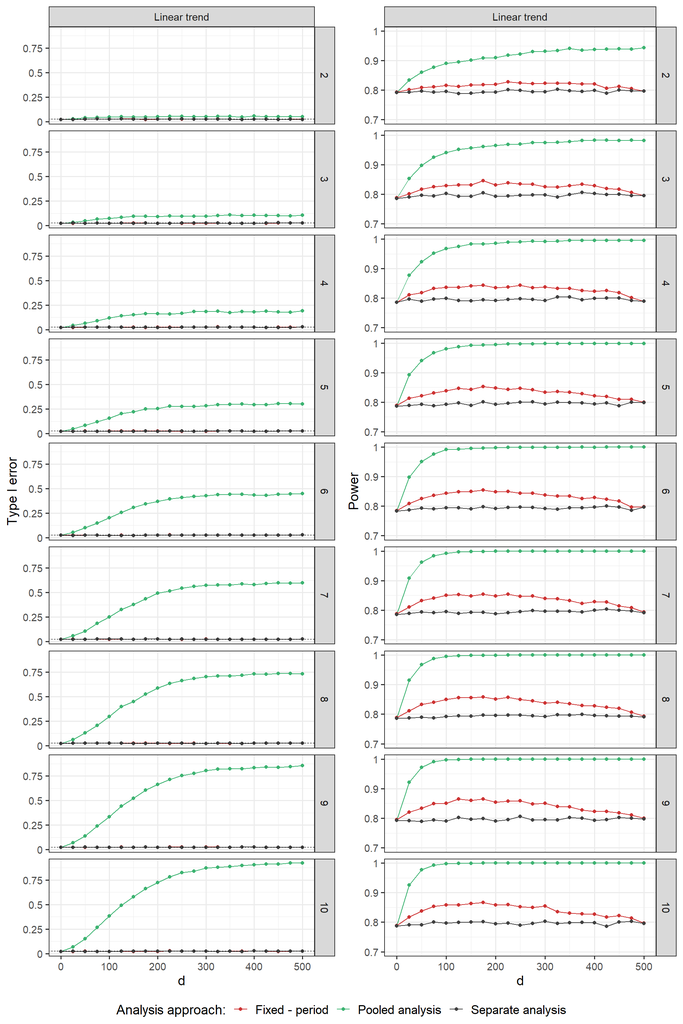

```r
ggarrange(ggplot(results_setting_1_alpha %>% filter(lambda0==0.5)) +
            annotate("rect", xmin = -Inf, xmax = Inf, ymin = pred_int[1], ymax = pred_int[2], fill = "gray54", alpha = 0.4) +
            geom_line(aes(d2, reject_h0, color=model)) +
            geom_point(aes(d2, reject_h0, color=model)) +
            labs(x=TeX("$d$"), y="Type I error", color="Analysis approach:") +
            geom_hline(aes(yintercept = 0.025), linetype = "dotted") +
            facet_grid(study_arm ~ trend,
                       labeller = labeller(trend  = as_labeller(trend_names))) +
            scale_y_continuous(labels = function(x) sub(".0+$", "", x)) +
            # coord_cartesian(ylim = c(0, 0.3)) +
            scale_color_manual(labels = c("Fixed - period", "Pooled analysis", "Separate analysis"), values = my_palette, limits = force) +
            theme_bw(base_size = 13.8) +
            theme(legend.text=element_text(size = 13)),

          ggplot(results_setting_1_pow %>% filter(lambda0==0.5)) +
            geom_line(aes(d2, reject_h0, color=model)) +
            geom_point(aes(d2, reject_h0, color=model)) +
            labs(x=TeX("$d$"), y="Power", color="Analysis approach:") +
            facet_grid(study_arm ~ trend,
                       labeller = labeller(trend  = as_labeller(trend_names))) +
            scale_y_continuous(labels = function(x) sub(".0+$", "", x)) +
            coord_cartesian(ylim = c(0.70, 1)) +
            scale_color_manual(labels = c("Fixed - period", "Pooled analysis", "Separate analysis"), values = my_palette, limits = force) +
            theme_bw(base_size = 13.8) +
            theme(legend.text=element_text(size = 13)),

          common.legend = T, legend = "bottom") +
  bgcolor("white") +
  border("white")
```

```r
ggsave("figures/fixmodel_alpha_pow_d_all_arms.png", width = 10, height = 15)
```

- $\lambda=0.5$
- $n=250$ per experimental treatment arm
- Rows - $d$
- T1E and power with respect to the index of the evaluated arm

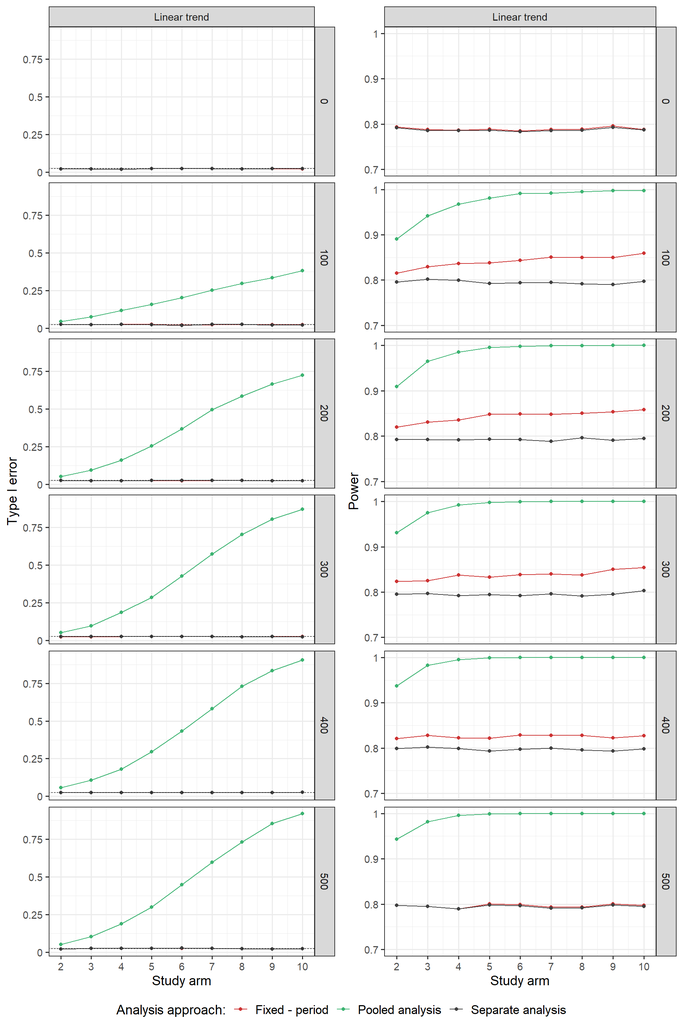

```r
ggarrange(ggplot(results_setting_1_alpha %>% filter(d2 %in% c(0, 100, 200, 300, 400, 500) & lambda0==0.5)) +
            annotate("rect", xmin = -Inf, xmax = Inf, ymin = pred_int[1], ymax = pred_int[2], fill = "gray54", alpha = 0.4) +
            geom_line(aes(study_arm, reject_h0, color=model)) +
            geom_point(aes(study_arm, reject_h0, color=model)) +
            labs(x="Study arm", y="Type I error", color="Analysis approach:") +
            geom_hline(aes(yintercept = 0.025), linetype = "dotted") +
            facet_grid(d2 ~ trend,
                       labeller = labeller(trend  = as_labeller(trend_names))) +
            #coord_cartesian(ylim = c(0, 0.3)) +
            scale_color_manual(labels = c("Fixed - period", "Pooled analysis", "Separate analysis"), values = my_palette, limits = force) +
            scale_x_continuous(breaks = c(1:10), labels = c(1:10)) +
            scale_y_continuous(labels = function(x) sub(".0+$", "", x)) +
            theme_bw(base_size = 13.8) +
            theme(legend.text=element_text(size = 13)),

          ggplot(results_setting_1_pow %>% filter(d2 %in% c(0, 100, 200, 300, 400, 500) & lambda0==0.5)) +
            geom_line(aes(study_arm, reject_h0, color=model)) +
            geom_point(aes(study_arm, reject_h0, color=model)) +
            labs(x="Study arm", y="Power", color="Analysis approach:") +
            facet_grid(d2 ~ trend,
                       labeller = labeller(trend  = as_labeller(trend_names))) +
            coord_cartesian(ylim = c(0.70, 1)) +
            scale_color_manual(labels = c("Fixed - period", "Pooled analysis", "Separate analysis"), values = my_palette, limits = force) +
            scale_x_continuous(breaks = c(1:10), labels = c(1:10)) +
            scale_y_continuous(labels = function(x) sub(".0+$", "", x)) +
            theme_bw(base_size = 13.8) +
            theme(legend.text=element_text(size = 13)),

          common.legend = T, legend = "bottom") +
  bgcolor("white") +
  border("white")
```

```r
ggsave("figures/fixmodel_alpha_pow_study_arm_all_d.png", width = 10, height = 15)
```

# SETTING 2 - 4 treatment arms

## Plots from Chapter 3

### Scenario illustration

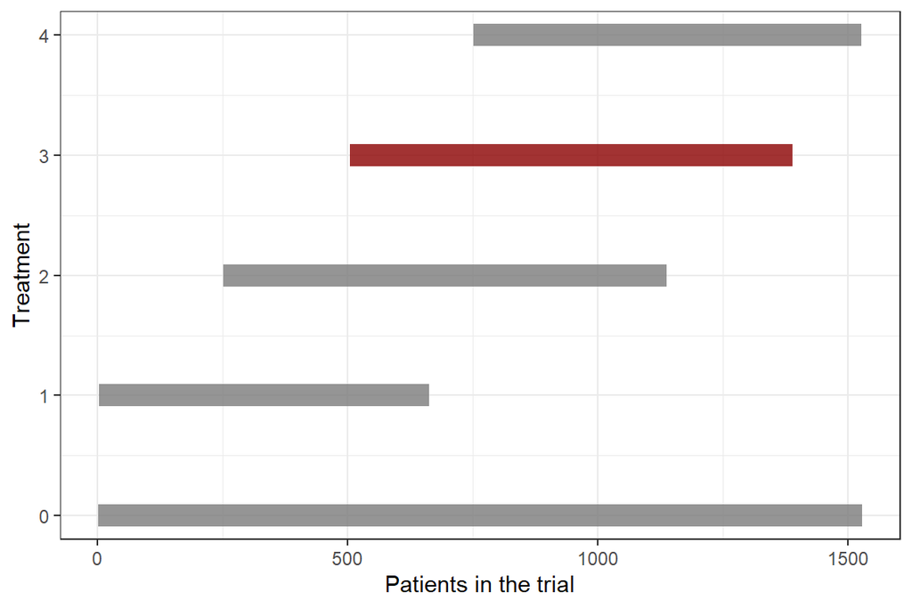

```r
d <- 250
trial_data <- datasim_cont(num_arms = 4, n_arm = 250, d = d*c(0:3), theta = rep(0, 4), lambda = rep(0.5, 5), sigma = 1, trend = "stepwise_2", full = T)$Data

plot_trial(trial_data$treatment) +
  theme(plot.title = element_text(hjust = 0.5)) +
  scale_color_manual(values = c(rep("gray48", 3), "darkred", rep("gray48", 1)))
```

```r
ggsave("figures/trial_4arms.png", width = 6, height = 4)
```

### Results

- Evaluated arm: 3
- $\lambda=0.125$
- $n=250$ per experimental treatment arm
- $N_p=750$ for inverted-U time trend (corresponding approximately to the middle of the trial)
- T1E and power with respect to the size of the calendar time unit under different time trend patterns

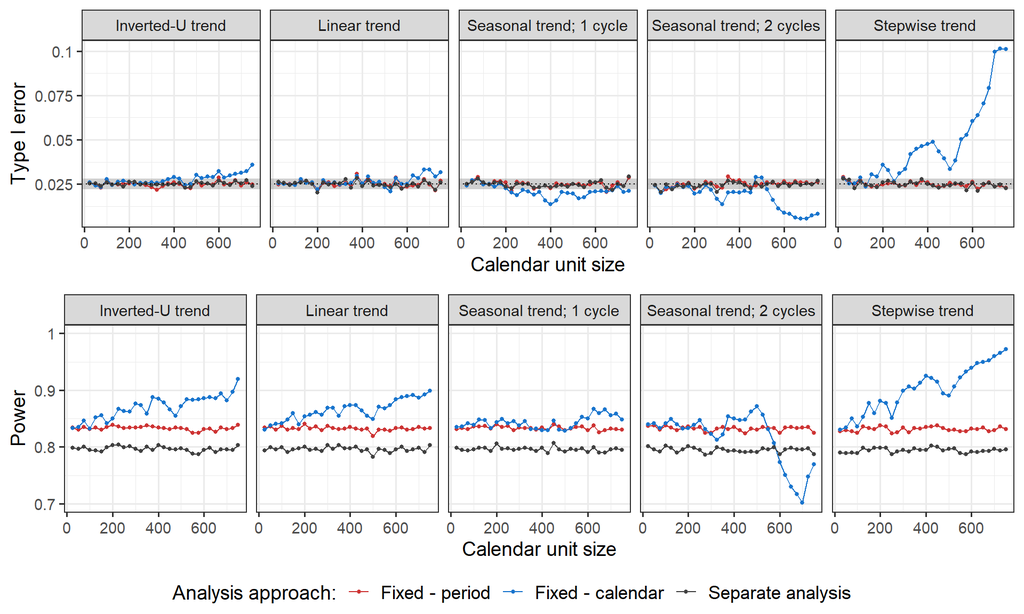

```r
ggarrange(ggplot(results_setting_2_alpha %>% filter(study_arm==3, lambda1==0.125)) +
            annotate("rect", xmin = -Inf, xmax = Inf, ymin = pred_int[1], ymax = pred_int[2], fill = "gray54", alpha = 0.4) +
            geom_line(aes(unit_size, reject_h0, color = as.factor(model))) +
            geom_point(aes(unit_size, reject_h0, color = as.factor(model)), size = 1) +
            labs(x="Calendar unit size", y="Type I error", color="Analysis approach:") +
            scale_color_manual(labels = c("Fixed - period", "Fixed - calendar", "Separate analysis"), values = my_palette, limits = force) +
            geom_hline(aes(yintercept = 0.025), linetype = "dotted") +
            #coord_cartesian(ylim = c(0, 0.1)) +
            facet_grid(~ trend,
                       labeller = labeller(trend  = as_labeller(trend_names))) +
            scale_y_continuous(labels = function(x) sub(".0+$", "", x)) +
            theme_bw(base_size = 13.8) +
            theme(legend.text=element_text(size = 13)),

          ggplot(results_setting_2_pow %>% filter(study_arm==3, lambda1==0.125)) +
            geom_line(aes(unit_size, reject_h0, color = as.factor(model))) +
            geom_point(aes(unit_size, reject_h0, color = as.factor(model)), size = 1) +
            labs(x="Calendar unit size", y="Power", color="Analysis approach:") +
            scale_color_manual(labels = c("Fixed - period", "Fixed - calendar", "Separate analysis"), values = my_palette, limits = force) +
            coord_cartesian(ylim = c(0.70, 1)) +
            facet_grid(~ trend,
                       labeller = labeller(trend  = as_labeller(trend_names))) +
            scale_y_continuous(labels = function(x) sub(".0+$", "", x)) +
            theme_bw(base_size = 13.8) +
            theme(legend.text=element_text(size = 13)),

          common.legend = T, legend = "bottom",
          nrow = 2) +
  bgcolor("white") +
  border("white")
```

```r
ggsave("figures/fixmodel_cal_alpha_pow_unit.png", width = 10, height = 6)
```

- Evaluated arm: 3
- Calendar time unit size: 100
- $n=250$ per experimental treatment arm
- $N_p=750$ for inverted-U time trend (corresponding approximately to the middle of the trial)
- T1E and power with respect to the strength of the time trend $\lambda$ under different time trend patterns

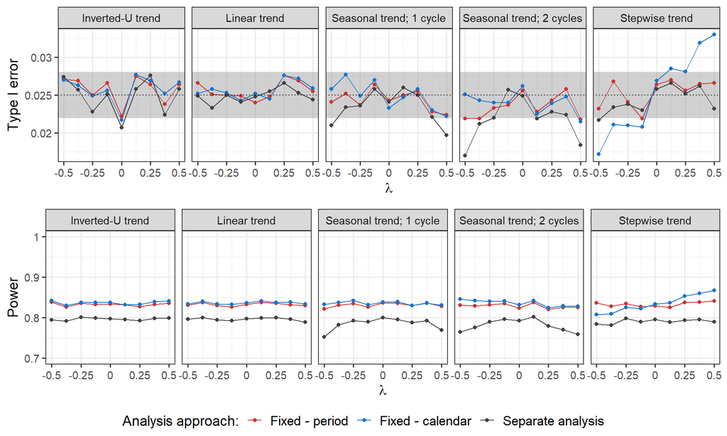

```r
ggarrange(ggplot(results_setting_2_alpha %>% filter(study_arm==3, unit_size==100)) +
            annotate("rect", xmin = -Inf, xmax = Inf, ymin = pred_int[1], ymax = pred_int[2], fill = "gray54", alpha = 0.4) +
            geom_line(aes(lambda1, reject_h0, color = as.factor(model))) +
            geom_point(aes(lambda1, reject_h0, color = as.factor(model))) +
            labs(x=TeX("$\\lambda$"), y="Type I error", color="Analysis approach:") +
            scale_color_manual(labels = c("Fixed - period", "Fixed - calendar", "Separate analysis"), values = my_palette, limits = force) +
            geom_hline(aes(yintercept = 0.025), linetype = "dotted") +
            #coord_cartesian(ylim = c(0, 0.1)) +
            facet_grid( ~ trend,
                        labeller = labeller(trend  = as_labeller(trend_names))) +
            scale_x_continuous(labels = function(x) sub(".0+$", "", x)) +
            scale_y_continuous(labels = function(x) sub(".0+$", "", x)) +
            theme_bw(base_size = 13.8) +
            theme(legend.text=element_text(size = 13)),

          ggplot(results_setting_2_pow %>% filter(study_arm==3, unit_size==100)) +
            geom_line(aes(lambda1, reject_h0, color = as.factor(model))) +
            geom_point(aes(lambda1, reject_h0, color = as.factor(model))) +
            labs(x=TeX("$\\lambda$"), y="Power", color="Analysis approach:") +
            scale_color_manual(labels = c("Fixed - period", "Fixed - calendar", "Separate analysis"), values = my_palette, limits = force) +
            coord_cartesian(ylim = c(0.70, 1)) +
            facet_grid( ~ trend,
                        labeller = labeller(trend  = as_labeller(trend_names))) +
            scale_x_continuous(labels = function(x) sub(".0+$", "", x)) +
            scale_y_continuous(labels = function(x) sub(".0+$", "", x)) +
            theme_bw(base_size = 13.8) +
            theme(legend.text=element_text(size = 13)),

          common.legend = T, legend = "bottom",
          nrow = 2) +
  bgcolor("white") +
  border("white")
```

```r
ggsave("figures/fixmodel_cal_alpha_pow_lambda.png", width = 10, height = 6)
```

## Plots from Appendix

- Evaluated arm: 3
- $n=250$ per experimental treatment arm
- $N_p=750$ for inverted-U time trend (corresponding approximately to the middle of the trial)
- Rows - Calendar time unit sizes
- T1E and power with respect to the strength of the time trend $\lambda$ under different time trend patterns

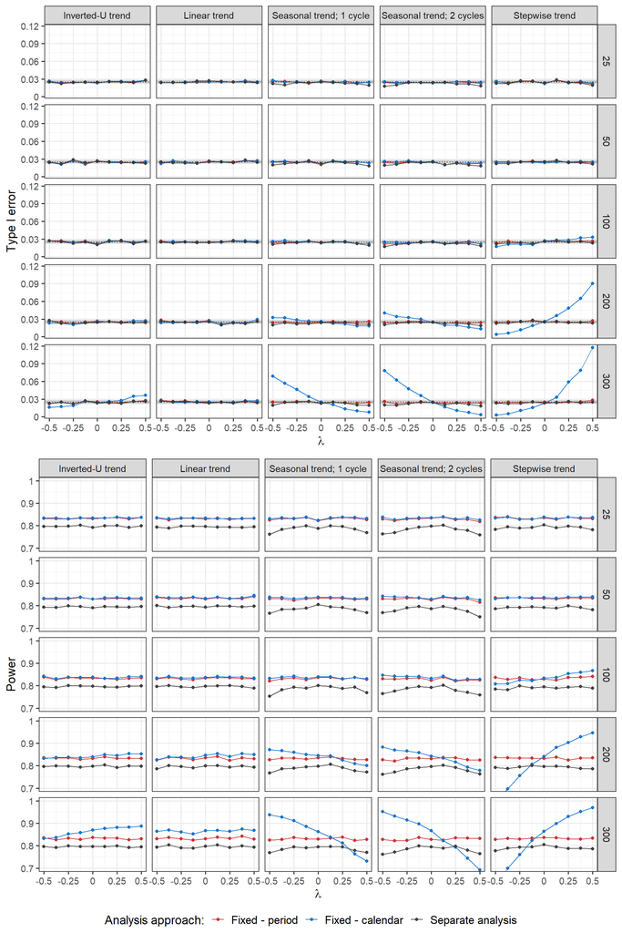

```r
ggarrange(ggplot(results_setting_2_alpha %>% filter(study_arm==3, unit_size %in% c(25, 50, 100, 200, 300))) +
            annotate("rect", xmin = -Inf, xmax = Inf, ymin = pred_int[1], ymax = pred_int[2], fill = "gray54", alpha = 0.4) +
            geom_line(aes(lambda1, reject_h0, color = as.factor(model))) +
            geom_point(aes(lambda1, reject_h0, color = as.factor(model))) +
            labs(x=TeX("$\\lambda$"), y="Type I error", color="Analysis approach:") +
            scale_color_manual(labels = c("Fixed - period", "Fixed - calendar", "Separate analysis"), values = my_palette, limits = force) +
            geom_hline(aes(yintercept = 0.025), linetype = "dotted") +
            #coord_cartesian(ylim = c(0, 0.1)) +
            facet_grid(unit_size ~ trend,
                       labeller = labeller(trend  = as_labeller(trend_names))) +
            scale_x_continuous(labels = function(x) sub(".0+$", "", x)) +
            scale_y_continuous(labels = function(x) sub(".0+$", "", x)) +
            theme_bw(base_size = 13.8) +
            theme(legend.text=element_text(size = 13)),

          ggplot(results_setting_2_pow %>% filter(study_arm==3, unit_size %in% c(25, 50, 100, 200, 300))) +
            geom_line(aes(lambda1, reject_h0, color = as.factor(model))) +
            geom_point(aes(lambda1, reject_h0, color = as.factor(model))) +
            labs(x=TeX("$\\lambda$"), y="Power", color="Analysis approach:") +
            scale_color_manual(labels = c("Fixed - period", "Fixed - calendar", "Separate analysis"), values = my_palette, limits = force) +
            coord_cartesian(ylim = c(0.70, 1)) +
            facet_grid(unit_size ~ trend,
                       labeller = labeller(trend  = as_labeller(trend_names))) +
            scale_x_continuous(labels = function(x) sub(".0+$", "", x)) +
            scale_y_continuous(labels = function(x) sub(".0+$", "", x)) +
            theme_bw(base_size = 13.8) +
            theme(legend.text=element_text(size = 13)),

          common.legend = T, legend = "bottom",
          nrow = 2) +
  bgcolor("white") +
  border("white")
```

```r
ggsave("figures/fixmodel_cal_alpha_pow_lambda_all_units.png", width = 10, height = 15)
```

- Calendar time unit size: 100
- $n=250$ per experimental treatment arm
- $N_p=750$ for inverted-U time trend (corresponding approximately to the middle of the trial)
- Rows - Evaluated arm
- T1E and power with respect to the strength of the time trend $\lambda$ under different time trend patterns

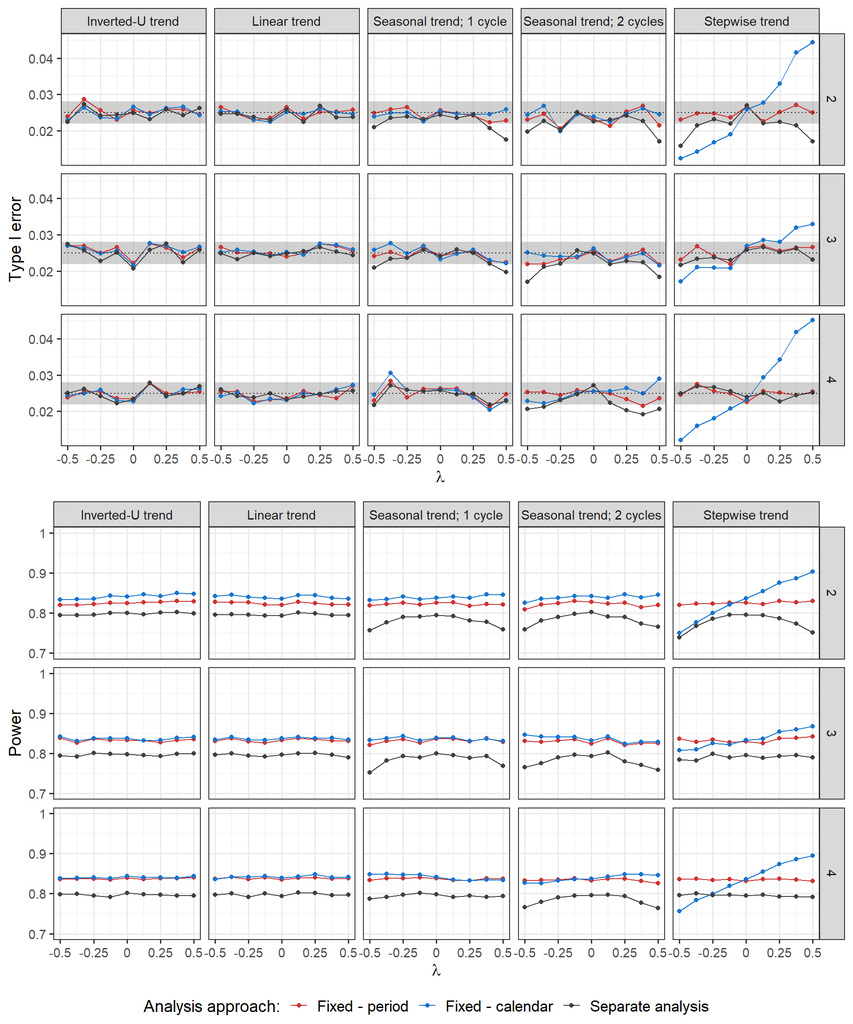

```r
ggarrange(ggplot(results_setting_2_alpha %>% filter(unit_size==100)) +
            annotate("rect", xmin = -Inf, xmax = Inf, ymin = pred_int[1], ymax = pred_int[2], fill = "gray54", alpha = 0.4) +
            geom_line(aes(lambda1, reject_h0, color = as.factor(model))) +
            geom_point(aes(lambda1, reject_h0, color = as.factor(model))) +
            labs(x=TeX("$\\lambda$"), y="Type I error", color="Analysis approach:") +
            scale_color_manual(labels = c("Fixed - period", "Fixed - calendar", "Separate analysis"), values = my_palette, limits = force) +
            geom_hline(aes(yintercept = 0.025), linetype = "dotted") +
            #coord_cartesian(ylim = c(0, 0.1)) +
            facet_grid(study_arm ~ trend,
                       labeller = labeller(trend  = as_labeller(trend_names))) +
            scale_x_continuous(labels = function(x) sub(".0+$", "", x)) +
            scale_y_continuous(labels = function(x) sub(".0+$", "", x)) +
            theme_bw(base_size = 13.8) +
            theme(legend.text=element_text(size = 13)),

          ggplot(results_setting_2_pow %>% filter(unit_size==100)) +
            geom_line(aes(lambda1, reject_h0, color = as.factor(model))) +
            geom_point(aes(lambda1, reject_h0, color = as.factor(model))) +
            labs(x=TeX("$\\lambda$"), y="Power", color="Analysis approach:") +
            scale_color_manual(labels = c("Fixed - period", "Fixed - calendar", "Separate analysis"), values = my_palette, limits = force) +
            coord_cartesian(ylim = c(0.70, 1)) +
            facet_grid(study_arm ~ trend,
                       labeller = labeller(trend  = as_labeller(trend_names))) +
            scale_x_continuous(labels = function(x) sub(".0+$", "", x)) +
            scale_y_continuous(labels = function(x) sub(".0+$", "", x)) +
            theme_bw(base_size = 13.8) +
            theme(legend.text=element_text(size = 13)),

          common.legend = T, legend = "bottom",
          nrow = 2) +
  bgcolor("white") +
  border("white")
```

```r
ggsave("figures/fixmodel_cal_alpha_pow_lambda_all_arms.png", width = 10, height = 12)
```

- $\lambda=0.125$
- $n=250$ per experimental treatment arm
- $N_p=750$ for inverted-U time trend (corresponding approximately to the middle of the trial)
- Rows - Evaluated arm
- T1E and power with respect to the size of the calendar time unit under different time trend patterns

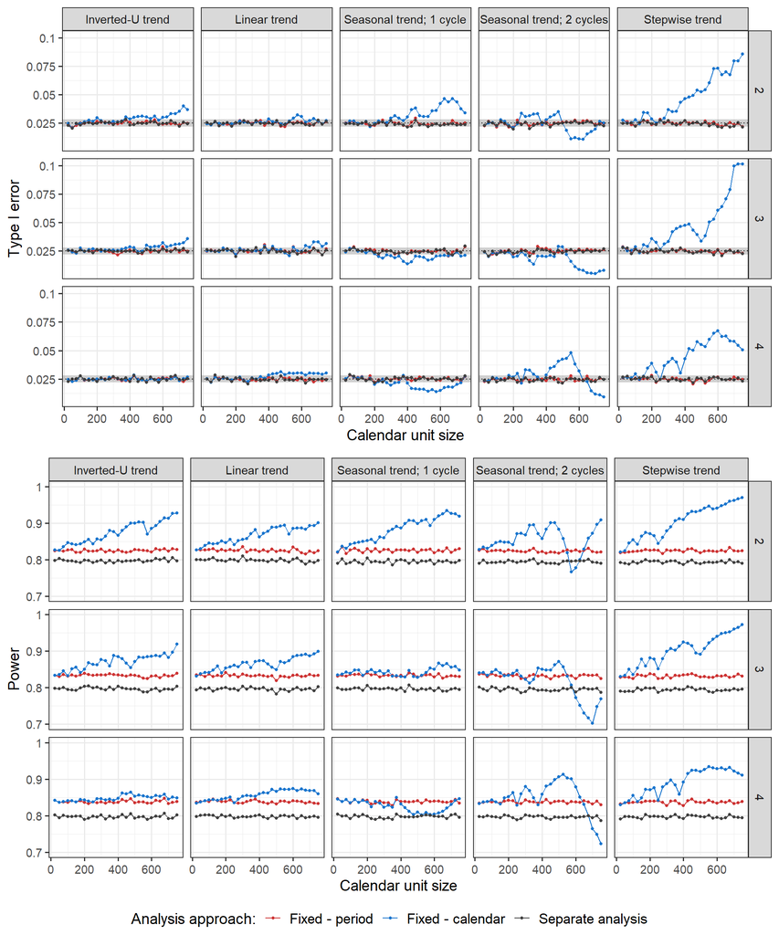

```r
ggarrange(ggplot(results_setting_2_alpha %>% filter(lambda1==0.125)) +
            annotate("rect", xmin = -Inf, xmax = Inf, ymin = pred_int[1], ymax = pred_int[2], fill = "gray54", alpha = 0.4) +
            geom_line(aes(unit_size, reject_h0, color = as.factor(model))) +
            geom_point(aes(unit_size, reject_h0, color = as.factor(model)), size = 1) +
            labs(x="Calendar unit size", y="Type I error", color="Analysis approach:") +
            scale_color_manual(labels = c("Fixed - period", "Fixed - calendar", "Separate analysis"), values = my_palette, limits = force) +
            geom_hline(aes(yintercept = 0.025), linetype = "dotted") +
            #coord_cartesian(ylim = c(0, 0.1)) +
            facet_grid(study_arm ~ trend,
                       labeller = labeller(trend  = as_labeller(trend_names))) +
            scale_y_continuous(labels = function(x) sub(".0+$", "", x)) +
            theme_bw(base_size = 13.8) +
            theme(legend.text=element_text(size = 13)),

          ggplot(results_setting_2_pow %>% filter(lambda1==0.125)) +
            geom_line(aes(unit_size, reject_h0, color = as.factor(model))) +
            geom_point(aes(unit_size, reject_h0, color = as.factor(model)), size = 1) +
            labs(x="Calendar unit size", y="Power", color="Analysis approach:") +
            scale_color_manual(labels = c("Fixed - period", "Fixed - calendar", "Separate analysis"), values = my_palette, limits = force) +
            coord_cartesian(ylim = c(0.70, 1)) +
            facet_grid(study_arm ~ trend,
                       labeller = labeller(trend  = as_labeller(trend_names))) +
            scale_y_continuous(labels = function(x) sub(".0+$", "", x)) +
            theme_bw(base_size = 13.8) +
            theme(legend.text=element_text(size = 13)),

          common.legend = T, legend = "bottom",
          nrow = 2) +
  bgcolor("white") +
  border("white")
```

```r
ggsave("figures/fixmodel_cal_alpha_pow_unit_all_arms.png", width = 10, height = 12)
```

# SETTING 3 - 4 treatment arms

## Plots from Chapter 3

### Results

- Evaluated arm: 3
- Calendar time unit size: 100
- $n=250$ per experimental treatment arm
- $N_p=750$ for inverted-U time trend (corresponding approximately to the middle of the trial)
- T1E and power with respect to the strength of the time trend $\lambda$ under different time trend patterns

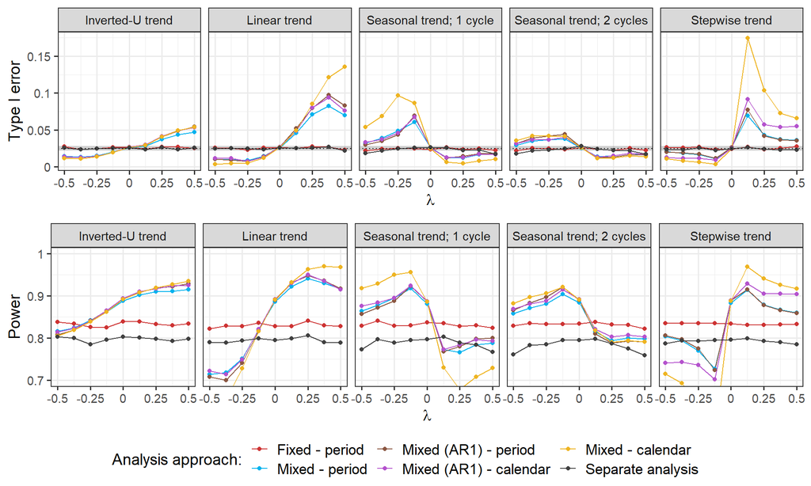

```r
ggarrange(ggplot(results_setting_3_alpha %>% filter(study_arm==3, unit_size==100)) +
            annotate("rect", xmin = -Inf, xmax = Inf, ymin = pred_int[1], ymax = pred_int[2], fill = "gray54", alpha = 0.4) +
            geom_line(aes(lambda1, reject_h0, color = as.factor(model))) +
            geom_point(aes(lambda1, reject_h0, color = as.factor(model))) +
            labs(x=TeX("$\\lambda$"), y="Type I error", color="Analysis approach:") +
            scale_color_manual(labels = c("Fixed - period", "Mixed - period", "Mixed (AR1) - period",
                                          "Mixed (AR1) - calendar", "Mixed - calendar", "Separate analysis"),
                               values = my_palette, limits = force) +
            geom_hline(aes(yintercept = 0.025), linetype = "dotted") +
            #coord_cartesian(ylim = c(0, 0.1)) +
            facet_grid(~ trend,
                       labeller = labeller(trend  = as_labeller(trend_names))) +
            scale_x_continuous(labels = function(x) sub(".0+$", "", x)) +
            scale_y_continuous(labels = function(x) sub(".0+$", "", x)) +
            theme_bw(base_size = 13.8) +
            theme(legend.text=element_text(size = 13)),

          ggplot(results_setting_3_pow %>% filter(study_arm==3, unit_size==100)) +
            geom_line(aes(lambda1, reject_h0, color = as.factor(model))) +
            geom_point(aes(lambda1, reject_h0, color = as.factor(model))) +
            labs(x=TeX("$\\lambda$"), y="Power", color="Analysis approach:") +
            scale_color_manual(labels = c("Fixed - period", "Mixed - period", "Mixed (AR1) - period",
                                          "Mixed (AR1) - calendar", "Mixed - calendar", "Separate analysis"),
                               values = my_palette, limits = force) +
            coord_cartesian(ylim = c(0.70, 1)) +
            facet_grid(~ trend,
                       labeller = labeller(trend  = as_labeller(trend_names))) +
            scale_x_continuous(labels = function(x) sub(".0+$", "", x)) +
            scale_y_continuous(labels = function(x) sub(".0+$", "", x)) +
            theme_bw(base_size = 13.8) +
            theme(legend.text=element_text(size = 13)),

          common.legend = T, legend = "bottom",
          nrow = 2) +
  bgcolor("white") +
  border("white")
```

```r
ggsave("figures/mixmodel_alpha_pow_lambda.png", width = 10, height = 6)
```

## Plots from Appendix

- Calendar time unit size: 100
- $n=250$ per experimental treatment arm
- $N_p=750$ for inverted-U time trend (corresponding approximately to the middle of the trial)
- Rows - Evaluated arm
- T1E and power with respect to the strength of the time trend $\lambda$ under different time trend patterns

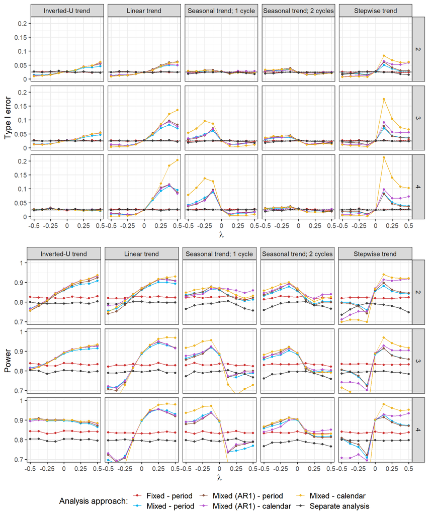

```r
ggarrange(ggplot(results_setting_3_alpha %>% filter(unit_size==100)) +
            annotate("rect", xmin = -Inf, xmax = Inf, ymin = pred_int[1], ymax = pred_int[2], fill = "gray54", alpha = 0.4) +
            geom_line(aes(lambda1, reject_h0, color = as.factor(model))) +
            geom_point(aes(lambda1, reject_h0, color = as.factor(model))) +
            labs(x=TeX("$\\lambda$"), y="Type I error", color="Analysis approach:") +
            scale_color_manual(labels = c("Fixed - period", "Mixed - period", "Mixed (AR1) - period",
                                          "Mixed (AR1) - calendar", "Mixed - calendar", "Separate analysis"),
                               values = my_palette, limits = force) +
            geom_hline(aes(yintercept = 0.025), linetype = "dotted") +
            #coord_cartesian(ylim = c(0, 0.1)) +
            facet_grid(study_arm ~ trend,
                       labeller = labeller(trend  = as_labeller(trend_names))) +
            scale_x_continuous(labels = function(x) sub(".0+$", "", x)) +
            scale_y_continuous(labels = function(x) sub(".0+$", "", x)) +
            theme_bw(base_size = 13.8) +
            theme(legend.text=element_text(size = 13)),

          ggplot(results_setting_3_pow %>% filter(unit_size==100)) +
            geom_line(aes(lambda1, reject_h0, color = as.factor(model))) +
            geom_point(aes(lambda1, reject_h0, color = as.factor(model))) +
            labs(x=TeX("$\\lambda$"), y="Power", color="Analysis approach:") +
            scale_color_manual(labels = c("Fixed - period", "Mixed - period", "Mixed (AR1) - period",
                                          "Mixed (AR1) - calendar", "Mixed - calendar", "Separate analysis"),
                               values = my_palette, limits = force) +
            coord_cartesian(ylim = c(0.70, 1)) +
            facet_grid(study_arm ~ trend,
                       labeller = labeller(trend  = as_labeller(trend_names))) +
            scale_x_continuous(labels = function(x) sub(".0+$", "", x)) +
            scale_y_continuous(labels = function(x) sub(".0+$", "", x)) +
            theme_bw(base_size = 13.8) +
            theme(legend.text=element_text(size = 13)),

          common.legend = T, legend = "bottom",
          nrow = 2) +
  bgcolor("white") +
  border("white")
```

```r
ggsave("figures/mixmodel_alpha_pow_lambda_all_arms.png", width = 10, height = 12)
```

- Evaluated arm: 3
- $n=250$ per experimental treatment arm
- $N_p=750$ for inverted-U time trend (corresponding approximately to the middle of the trial)
- Rows - Calendar time unit sizes
- T1E and power with respect to the strength of the time trend $\lambda$ under different time trend patterns

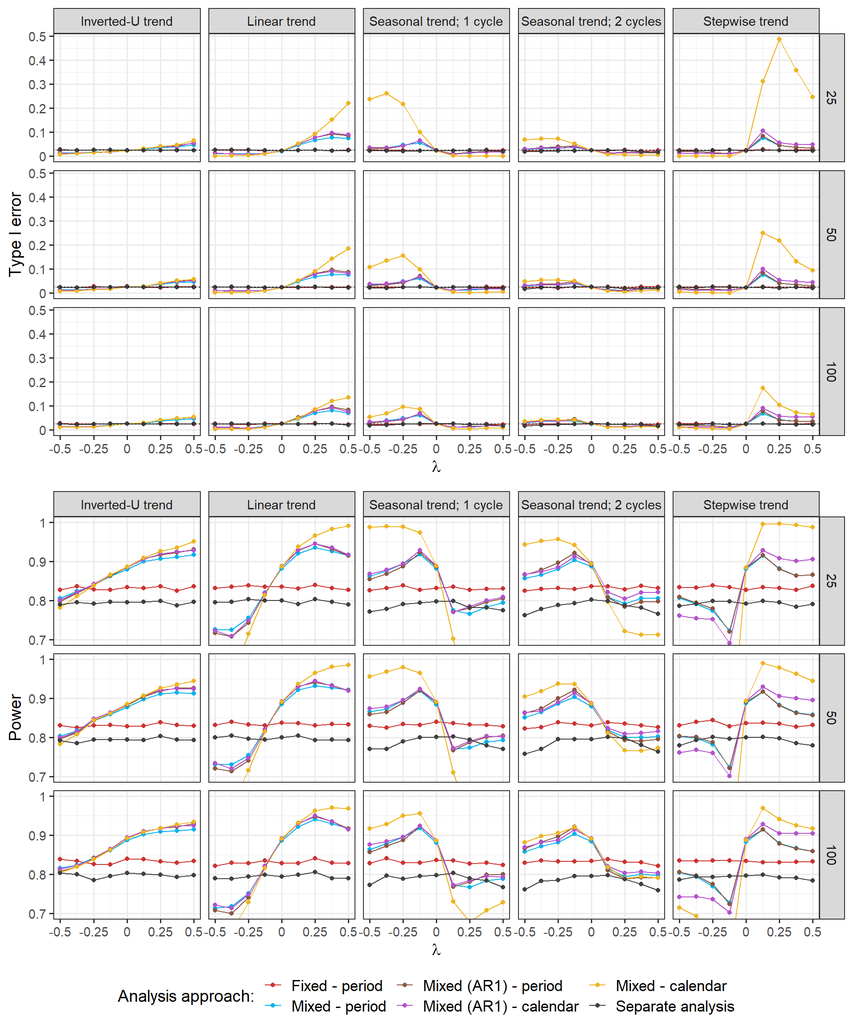

```r
ggarrange(ggplot(results_setting_3_alpha %>% filter(study_arm==3)) +
            annotate("rect", xmin = -Inf, xmax = Inf, ymin = pred_int[1], ymax = pred_int[2], fill = "gray54", alpha = 0.4) +
            geom_line(aes(lambda1, reject_h0, color = as.factor(model))) +
            geom_point(aes(lambda1, reject_h0, color = as.factor(model))) +
            labs(x=TeX("$\\lambda$"), y="Type I error", color="Analysis approach:") +
            scale_color_manual(labels = c("Fixed - period", "Mixed - period", "Mixed (AR1) - period",
                                          "Mixed (AR1) - calendar", "Mixed - calendar", "Separate analysis"),
                               values = my_palette, limits = force) +
            geom_hline(aes(yintercept = 0.025), linetype = "dotted") +
            #coord_cartesian(ylim = c(0, 0.1)) +
            facet_grid(unit_size ~ trend,
                       labeller = labeller(trend  = as_labeller(trend_names))) +
            scale_x_continuous(labels = function(x) sub(".0+$", "", x)) +
            scale_y_continuous(labels = function(x) sub(".0+$", "", x)) +
            theme_bw(base_size = 13.8) +
            theme(legend.text=element_text(size = 13)),

          ggplot(results_setting_3_pow %>% filter(study_arm==3)) +
            geom_line(aes(lambda1, reject_h0, color = as.factor(model))) +
            geom_point(aes(lambda1, reject_h0, color = as.factor(model))) +
            labs(x=TeX("$\\lambda$"), y="Power", color="Analysis approach:") +
            scale_color_manual(labels = c("Fixed - period", "Mixed - period", "Mixed (AR1) - period",
                                          "Mixed (AR1) - calendar", "Mixed - calendar", "Separate analysis"),
                               values = my_palette, limits = force) +
            coord_cartesian(ylim = c(0.70, 1)) +
            facet_grid(unit_size ~ trend,
                       labeller = labeller(trend  = as_labeller(trend_names))) +
            scale_x_continuous(labels = function(x) sub(".0+$", "", x)) +
            scale_y_continuous(labels = function(x) sub(".0+$", "", x)) +
            theme_bw(base_size = 13.8) +
            theme(legend.text=element_text(size = 13)),

          common.legend = T, legend = "bottom",
          nrow = 2) +
  bgcolor("white") +
  border("white")
```

```r
ggsave("figures/mixmodel_alpha_pow_lambda_all_units.png", width = 10, height = 12)
```

# SETTING 4 - 7 treatment arms

## Plots from Chapter 3

### Scenario illustration

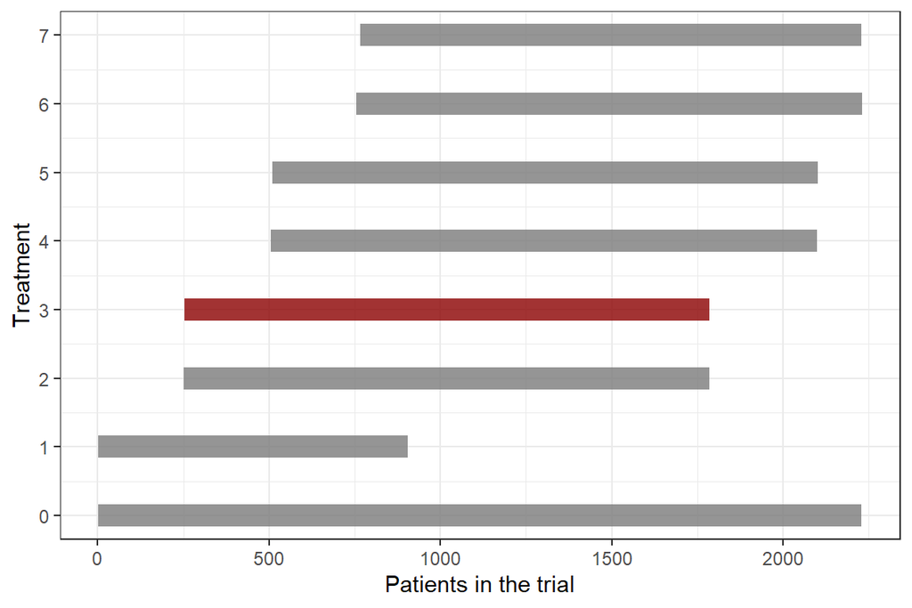

```r
d <- 250
trial_data <- datasim_cont(num_arms = 7, n_arm = 250, d = d*c(0,1,1,2,2,3,3), theta = rep(0, 7), lambda = rep(0.5, 8), sigma = 1, trend = "stepwise_2", full = T)$Data

plot_trial(trial_data$treatment) +
  scale_color_manual(values = c(rep("gray48", 3), "darkred", rep("gray48", 4)))
```

```r
ggsave("figures/trial_7arms.png", width = 6, height = 4)
```

### Results

- Evaluated arm: 3
- Degree of B-spline: 3 (cubic)
- Calendar time unit size: 100
- $n=250$ per experimental treatment arm
- $N_p=1115$ for inverted-U time trend (corresponding to the middle of the trial)
- T1E and power with respect to the strength of the time trend $\lambda$ under different time trend patterns

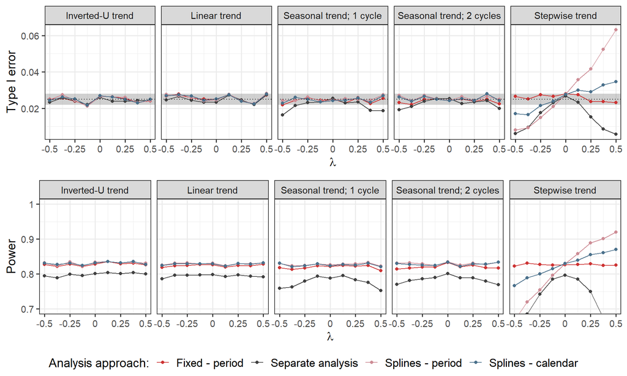

```r
ggarrange(ggplot(results_setting_4_alpha %>% filter(study_arm==3, bs_degree==3, unit_size==100)) +
            annotate("rect", xmin = -Inf, xmax = Inf, ymin = pred_int[1], ymax = pred_int[2], fill = "gray54", alpha = 0.4) +
            geom_line(aes(lambda1, reject_h0, color = as.factor(model))) +
            geom_point(aes(lambda1, reject_h0, color = as.factor(model))) +
            labs(x=TeX("$\\lambda$"), y="Type I error", color="Analysis approach:") +
            scale_color_manual(labels = c("Fixed - period", "Separate analysis", "Splines - period", "Splines - calendar"), values = my_palette, limits = force) +
            geom_hline(aes(yintercept = 0.025), linetype = "dotted") +
            #coord_cartesian(ylim = c(0, 0.1)) +
            facet_grid(~ trend,
                       labeller = labeller(trend = as_labeller(trend_names))) +
            scale_x_continuous(labels = function(x) sub(".0+$", "", x)) +
            scale_y_continuous(labels = function(x) sub(".0+$", "", x)) +
            theme_bw(base_size = 13.8) +
            theme(legend.text=element_text(size = 13)),

          ggplot(results_setting_4_pow %>% filter(study_arm==3, bs_degree==3, unit_size==100)) +
            geom_line(aes(lambda1, reject_h0, color = as.factor(model))) +
            geom_point(aes(lambda1, reject_h0, color = as.factor(model))) +
            labs(x=TeX("$\\lambda$"), y="Power", color="Analysis approach:") +
            scale_color_manual(labels = c("Fixed - period", "Separate analysis", "Splines - period", "Splines - calendar"), values = my_palette, limits = force) +
            coord_cartesian(ylim = c(0.70, 1)) +
            facet_grid(~ trend,
                       labeller = labeller(trend  = as_labeller(trend_names))) +
            scale_x_continuous(labels = function(x) sub(".0+$", "", x)) +
            scale_y_continuous(labels = function(x) sub(".0+$", "", x)) +
            theme_bw(base_size = 13.8) +
            theme(legend.text=element_text(size = 13)),

          common.legend = T, legend = "bottom",
          nrow = 2) +
  bgcolor("white") +
  border("white")
```

```r
ggsave("figures/splines_alpha_pow_lambda_trend.png", width = 10, height = 6)
```

## Plots from Appendix

- Degree of B-spline: 3 (cubic)
- Calendar time unit size: 100
- $n=250$ per experimental treatment arm
- $N_p=1115$ for inverted-U time trend (corresponding to the middle of the trial)
- Rows - Evaluated arm
- T1E and power with respect to the strength of the time trend $\lambda$ under different time trend patterns

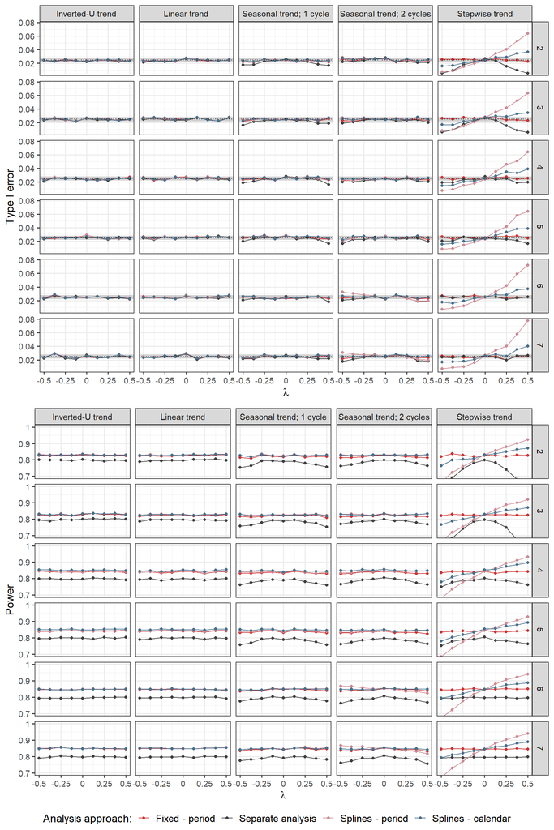

```r
ggarrange(ggplot(results_setting_4_alpha %>% filter(bs_degree==3, unit_size==100)) +
            annotate("rect", xmin = -Inf, xmax = Inf, ymin = pred_int[1], ymax = pred_int[2], fill = "gray54", alpha = 0.4) +
            geom_line(aes(lambda1, reject_h0, color = as.factor(model))) +
            geom_point(aes(lambda1, reject_h0, color = as.factor(model))) +
            labs(x=TeX("$\\lambda$"), y="Type I error", color="Analysis approach:") +
            scale_color_manual(labels = c("Fixed - period", "Separate analysis", "Splines - period", "Splines - calendar"), values = my_palette, limits = force) +
            geom_hline(aes(yintercept = 0.025), linetype = "dotted") +
            #coord_cartesian(ylim = c(0, 0.1)) +
            facet_grid(study_arm ~ trend,
                       labeller = labeller(trend = as_labeller(trend_names))) +
            scale_x_continuous(labels = function(x) sub(".0+$", "", x)) +
            scale_y_continuous(labels = function(x) sub(".0+$", "", x)) +
            theme_bw(base_size = 13.8) +
            theme(legend.text=element_text(size = 13)),

          ggplot(results_setting_4_pow %>% filter(bs_degree==3, unit_size==100)) +
            geom_line(aes(lambda1, reject_h0, color = as.factor(model))) +
            geom_point(aes(lambda1, reject_h0, color = as.factor(model))) +
            labs(x=TeX("$\\lambda$"), y="Power", color="Analysis approach:") +
            scale_color_manual(labels = c("Fixed - period", "Separate analysis", "Splines - period", "Splines - calendar"), values = my_palette, limits = force) +
            coord_cartesian(ylim = c(0.70, 1)) +
            facet_grid(study_arm ~ trend,
                       labeller = labeller(trend  = as_labeller(trend_names))) +
            scale_x_continuous(labels = function(x) sub(".0+$", "", x)) +
            scale_y_continuous(labels = function(x) sub(".0+$", "", x)) +
            theme_bw(base_size = 13.8) +
            theme(legend.text=element_text(size = 13)),

          common.legend = T, legend = "bottom",
          nrow = 2) +
  bgcolor("white") +
  border("white")
```

```r
ggsave("figures/splines_alpha_pow_lambda_trend_all_arms.png", width = 10, height = 15)
```

- Evaluated arm: 3
- Degree of B-spline: 3 (cubic)
- $n=250$ per experimental treatment arm
- $N_p=1115$ for inverted-U time trend (corresponding to the middle of the trial)
- Rows - Calendar time unit sizes
- T1E and power with respect to the strength of the time trend $\lambda$ under different time trend patterns

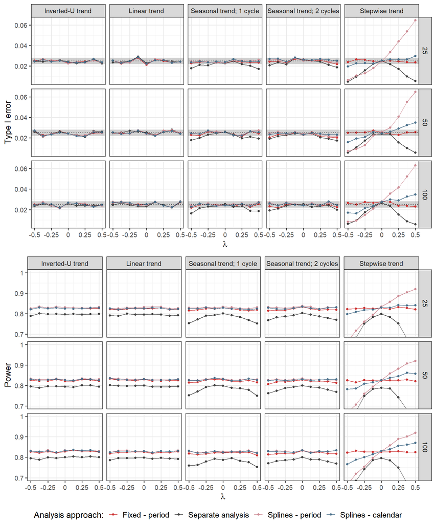

```r
ggarrange(ggplot(results_setting_4_alpha %>% filter(study_arm==3, bs_degree==3)) +
            annotate("rect", xmin = -Inf, xmax = Inf, ymin = pred_int[1], ymax = pred_int[2], fill = "gray54", alpha = 0.4) +
            geom_line(aes(lambda1, reject_h0, color = as.factor(model))) +
            geom_point(aes(lambda1, reject_h0, color = as.factor(model))) +
            labs(x=TeX("$\\lambda$"), y="Type I error", color="Analysis approach:") +
            scale_color_manual(labels = c("Fixed - period", "Separate analysis", "Splines - period", "Splines - calendar"), values = my_palette, limits = force) +
            geom_hline(aes(yintercept = 0.025), linetype = "dotted") +
            #coord_cartesian(ylim = c(0, 0.1)) +
            facet_grid(unit_size ~ trend,
                       labeller = labeller(trend = as_labeller(trend_names))) +
            scale_x_continuous(labels = function(x) sub(".0+$", "", x)) +
            scale_y_continuous(labels = function(x) sub(".0+$", "", x)) +
            theme_bw(base_size = 13.8) +
            theme(legend.text=element_text(size = 13)),

          ggplot(results_setting_4_pow %>% filter(study_arm==3, bs_degree==3)) +
            geom_line(aes(lambda1, reject_h0, color = as.factor(model))) +
            geom_point(aes(lambda1, reject_h0, color = as.factor(model))) +
            labs(x=TeX("$\\lambda$"), y="Power", color="Analysis approach:") +
            scale_color_manual(labels = c("Fixed - period", "Separate analysis", "Splines - period", "Splines - calendar"), values = my_palette, limits = force) +
            coord_cartesian(ylim = c(0.70, 1)) +
            facet_grid(unit_size ~ trend,
                       labeller = labeller(trend  = as_labeller(trend_names))) +
            scale_x_continuous(labels = function(x) sub(".0+$", "", x)) +
            scale_y_continuous(labels = function(x) sub(".0+$", "", x)) +
            theme_bw(base_size = 13.8) +
            theme(legend.text=element_text(size = 13)),

          common.legend = T, legend = "bottom",
          nrow = 2) +
  bgcolor("white") +
  border("white")
```

```r
ggsave("figures/splines_alpha_pow_lambda_trend_all_units.png", width = 10, height = 12)
```

- Evaluated arm: 3
- Calendar time unit size: 100
- $n=250$ per experimental treatment arm
- $N_p=1115$ for inverted-U time trend (corresponding to the middle of the trial)
- Rows - Degrees of B-splines
- T1E and power with respect to the strength of the time trend $\lambda$ under different time trend patterns

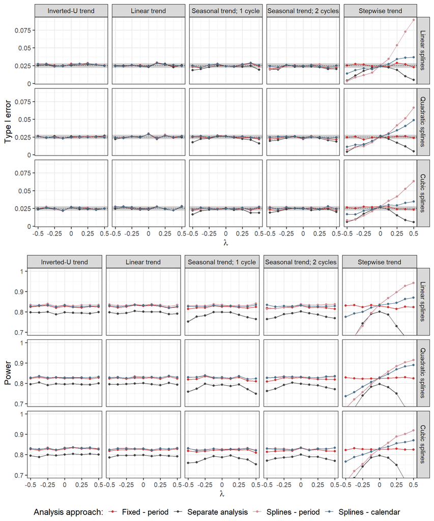

```r
ggarrange(ggplot(results_setting_4_alpha %>% filter(study_arm==3, unit_size==100)) +
            annotate("rect", xmin = -Inf, xmax = Inf, ymin = pred_int[1], ymax = pred_int[2], fill = "gray54", alpha = 0.4) +
            geom_line(aes(lambda1, reject_h0, color = as.factor(model))) +
            geom_point(aes(lambda1, reject_h0, color = as.factor(model))) +
            labs(x=TeX("$\\lambda$"), y="Type I error", color="Analysis approach:") +
            scale_color_manual(labels = c("Fixed - period", "Separate analysis", "Splines - period", "Splines - calendar"), values = my_palette, limits = force) +
            geom_hline(aes(yintercept = 0.025), linetype = "dotted") +
            #coord_cartesian(ylim = c(0, 0.1)) +
            facet_grid(bs_degree ~ trend,
                       labeller = labeller(trend = as_labeller(trend_names),
                                           bs_degree = as_labeller(degree_names))) +
            scale_x_continuous(labels = function(x) sub(".0+$", "", x)) +
            scale_y_continuous(labels = function(x) sub(".0+$", "", x)) +
            theme_bw(base_size = 13.8) +
            theme(legend.text=element_text(size = 13)),

          ggplot(results_setting_4_pow %>% filter(study_arm==3, unit_size==100)) +
            geom_line(aes(lambda1, reject_h0, color = as.factor(model))) +
            geom_point(aes(lambda1, reject_h0, color = as.factor(model))) +
            labs(x=TeX("$\\lambda$"), y="Power", color="Analysis approach:") +
            scale_color_manual(labels = c("Fixed - period", "Separate analysis", "Splines - period", "Splines - calendar"), values = my_palette, limits = force) +
            coord_cartesian(ylim = c(0.70, 1)) +
            facet_grid(bs_degree ~ trend,
                       labeller = labeller(trend  = as_labeller(trend_names),
                                           bs_degree = as_labeller(degree_names))) +
            scale_x_continuous(labels = function(x) sub(".0+$", "", x)) +
            scale_y_continuous(labels = function(x) sub(".0+$", "", x)) +
            theme_bw(base_size = 13.8) +
            theme(legend.text=element_text(size = 13)),

          common.legend = T, legend = "bottom",
          nrow = 2) +
  bgcolor("white") +
  border("white")
```

```r
ggsave("figures/splines_alpha_pow_lambda_trend_all_degrees.png", width = 10, height = 12)
```